# Google Data Analytics Case Study track1

Aditya Chaudhary

2023-08-31

# Case Study: How Does a Bike-Share Navigate Speedy Success?

## Case Study Description

The main goal of this case study is to perform multiple real-world tasks as junior data analyst and to answer the key business questions and suggest the proper solutions to the problem in the company using 6 steps of data analysis process that are ask, prepare, process, analyze, share and act.

## Business Task

Analyze usage patterns of casual riders and annual members at Cyclistic bike-share company in Chicago to inform the creation of a data-driven marketing strategy for converting casual riders to annual members.

## Step 1. Ask Phase:

Firstly, we need to know who our stakeholders are. The main stakeholders for this case study are:  
Lily Moreno: Director of marketing and my manager.  
Cyclistic executive team: Team that decides the approval of recommended marketing program.  
Cyclistic marketing analytics team: A group of data analyst whose job is to collect, analyze, and report data that helps guide Cyclistic marketing strategy.

Business Objectives:  
1. How do annual members and casual riders use Cyclistic bikes differently?  
2. Why would casual riders buy Cyclistic annual memberships?  
3. How can Cyclistic use digital media to influence casual riders to become members?

## Step 2. Prepare Phase:

### Data acquisition process

The data is taken from https://divvy-tripdata.s3.amazonaws.com/index.html and appropriately stored in the folder for original dataset. This is public data made available by Motivate International Inc. under the license https://www.divvybikes.com/data-license-agreement.

### Accessibility and privacy of the data

This is public data that we can use to explore how different customer types are using Cyclistic bikes. But note that data-privacy issues prohibit anyone from using riders’ personally identifiable information. This means that we cannot connect pass purchases to credit card numbers to determine if casual riders live in the Cyclistic service area or if they have purchased multiple single passes.

### Identifying issues with data

To check the issues with the data we need to calculate the ride length and find the unusable ride lengths and unusual observations like same starting and ending point, null values and inconsistent data types.

## Step 3. Process Phase:

In this phase, we clean, format, and ensure the data integrity so that it is complete, correct and relevant for analysis phase. I will use R to prepare, clean, transform, organize and summarize data due to its accessibility and capability to handle large datasets and it will enable me to create informative data visualizations for sharing the outcomes with my stakeholders.

Importing Libraries

```r
library(tidyverse)
```

```r
library(ggplot2)
library(lubridate)
```

Importing datasets

```r
df_q2_2019 <- read_csv("C:/../video/dddd/Data Analytics/course 8 capstone/datasets/last 12 months of datasets/Divvy_Trips_2019_Q2.csv")
df_q3_2019 <- read_csv("C:/../video/dddd/Data Analytics/course 8 capstone/datasets/last 12 months of datasets/Divvy_Trips_2019_Q3.csv")
df_q4_2019 <- read_csv("C:/../video/dddd/Data Analytics/course 8 capstone/datasets/last 12 months of datasets/Divvy_Trips_2019_Q4.csv")
df_q1_2020 <- read_csv("C:/../video/dddd/Data Analytics/course 8 capstone/datasets/last 12 months of datasets/Divvy_Trips_2020_Q1.csv")
```

Renaming columns to make consistent column names in all datasets so that we can merge later  
in df_q2_2019

```r
df_q2_2019 <- df_q2_2019 %>%
  rename('Ride_id'='01 - Rental Details Rental ID',
         'Start_Time'='01 - Rental Details Local Start Time',
         'End_Time'='01 - Rental Details Local End Time',
         'Bike_id'='01 - Rental Details Bike ID',
         'Trip_Duration_secs'='01 - Rental Details Duration In Seconds Uncapped',
         'From_Station_id'='03 - Rental Start Station ID',
         'From_Station_Name'='03 - Rental Start Station Name',
         'To_Station_id'='02 - Rental End Station ID',
         'To_Station_Name'='02 - Rental End Station Name',
         'User_type'='User Type',
         'Gender'='Member Gender',
         'Birth_Year'='05 - Member Details Member Birthday Year'
  )
```

in df_q3_2019

```r
df_q3_2019 <- df_q3_2019 %>%
  rename('Ride_id'='trip_id',
         'Start_Time'='start_time',
         'End_Time'='end_time',
         'Bike_id'='bikeid',
         'Trip_Duration_secs'='tripduration',
         'From_Station_id'='from_station_id',
         'From_Station_Name'='from_station_name',
         'To_Station_id'='to_station_id',
         'To_Station_Name'='to_station_name',
         'User_type'='usertype',
         'Gender'='gender',
         'Birth_Year'='birthyear'
  )
```

in_df_q4_2019

```r
df_q4_2019 <- df_q4_2019 %>%
  rename('Ride_id'='trip_id',
         'Start_Time'='start_time',
         'End_Time'='end_time',
         'Bike_id'='bikeid',
         'Trip_Duration_secs'='tripduration',
         'From_Station_id'='from_station_id',
         'From_Station_Name'='from_station_name',
         'To_Station_id'='to_station_id',
         'To_Station_Name'='to_station_name',
         'User_type'='usertype',
         'Gender'='gender',
         'Birth_Year'='birthyear'
  )
```

in df_q1_2020

```r
df_q1_2020 <- df_q1_2020 %>%
  rename('Ride_id'='ride_id',
         'Start_Time'='started_at',
         'End_Time'='ended_at',
         'Bike_id'='rideable_type',
         'From_Station_id'='start_station_id',
         'From_Station_Name'='start_station_name',
         'To_Station_id'='end_station_id',
         'To_Station_Name'='end_station_name',
         'User_type'='member_casual'
  )
```

Now we need to combine all the dataframe into the big dataframe but first we need to check the datatypes of all the columns in each dataframe to make them consistent in each dataframe

using the following function for quick analysis

```r
glimpse(df_q2_2019)
```

```
## Rows: 1,048,575
## Columns: 12
## $ Ride_id            <dbl> 22178529, 22178530, 22178531, 22178532, 22178533, 2…
## $ Start_Time         <chr> "4/1/2019 0:02", "4/1/2019 0:03", "4/1/2019 0:11", …
## $ End_Time           <chr> "4/1/2019 0:09", "4/1/2019 0:20", "4/1/2019 0:15", …
## $ Bike_id            <dbl> 6251, 6226, 5649, 4151, 3270, 3123, 6418, 4513, 328…
## $ Trip_Duration_secs <dbl> 446, 1048, 252, 357, 1007, 257, 548, 383, 2137, 212…
## $ From_Station_id    <dbl> 81, 317, 283, 26, 202, 420, 503, 260, 211, 211, 304…
## $ From_Station_Name  <chr> "Daley Center Plaza", "Wood St & Taylor St", "LaSal…
## $ To_Station_id      <dbl> 56, 59, 174, 133, 129, 426, 500, 499, 211, 211, 232…
## $ To_Station_Name    <chr> "Desplaines St & Kinzie St", "Wabash Ave & Roosevel…
## $ User_type          <chr> "Subscriber", "Subscriber", "Subscriber", "Subscrib…
## $ Gender             <chr> "Male", "Female", "Male", "Male", "Male", "Male", "…
## $ Birth_Year         <dbl> 1975, 1984, 1990, 1993, 1992, 1999, 1969, 1991, NA,…
```

```r
glimpse(df_q3_2019)
```

```
## Rows: 1,048,575
## Columns: 12
## $ Ride_id            <dbl> 23479388, 23479389, 23479390, 23479391, 23479392, 2…
## $ Start_Time         <chr> "7/1/2019 0:00", "7/1/2019 0:01", "7/1/2019 0:01", …
## $ End_Time           <chr> "7/1/2019 0:20", "7/1/2019 0:18", "7/1/2019 0:27", …
## $ Bike_id            <dbl> 3591, 5353, 6180, 5540, 6014, 4941, 3770, 5442, 295…
## $ Trip_Duration_secs <dbl> 1214, 1048, 1554, 1503, 1213, 310, 1248, 1550, 1583…
## $ From_Station_id    <dbl> 117, 381, 313, 313, 168, 300, 168, 313, 43, 43, 511…
## $ From_Station_Name  <chr> "Wilton Ave & Belmont Ave", "Western Ave & Monroe S…
## $ To_Station_id      <dbl> 497, 203, 144, 144, 62, 232, 62, 144, 195, 195, 84,…
## $ To_Station_Name    <chr> "Kimball Ave & Belmont Ave", "Western Ave & 21st St…
## $ User_type          <chr> "Subscriber", "Customer", "Customer", "Customer", "…
## $ Gender             <chr> "Male", NA, NA, NA, NA, "Male", NA, NA, NA, NA, NA,…
## $ Birth_Year         <dbl> 1992, NA, NA, NA, NA, 1990, NA, NA, NA, NA, NA, NA,…
```

```r
glimpse(df_q4_2019)
```

```
## Rows: 704,054
## Columns: 12
## $ Ride_id            <dbl> 25223640, 25223641, 25223642, 25223643, 25223644, 2…
## $ Start_Time         <chr> "10/1/2019 0:01", "10/1/2019 0:02", "10/1/2019 0:04…
## $ End_Time           <chr> "10/1/2019 0:17", "10/1/2019 0:06", "10/1/2019 0:18…
## $ Bike_id            <dbl> 2215, 6328, 3003, 3275, 5294, 1891, 1061, 1274, 601…
## $ Trip_Duration_secs <dbl> 940, 258, 850, 2350, 1867, 373, 1072, 1458, 1437, 8…
## $ From_Station_id    <dbl> 20, 19, 84, 313, 210, 156, 84, 156, 156, 336, 77, 1…
## $ From_Station_Name  <chr> "Sheffield Ave & Kingsbury St", "Throop (Loomis) St…
## $ To_Station_id      <dbl> 309, 241, 199, 290, 382, 226, 142, 463, 463, 336, 5…
## $ To_Station_Name    <chr> "Leavitt St & Armitage Ave", "Morgan St & Polk St",…
## $ User_type          <chr> "Subscriber", "Subscriber", "Subscriber", "Subscrib…
## $ Gender             <chr> "Male", "Male", "Female", "Male", "Male", "Female",…
## $ Birth_Year         <dbl> 1987, 1998, 1991, 1990, 1987, 1994, 1991, 1995, 199…
```

```r
glimpse(df_q1_2020)
```

```
## Rows: 426,887
## Columns: 13
## $ Ride_id           <chr> "EACB19130B0CDA4A", "8FED874C809DC021", "789F3C21E47…
## $ Bike_id           <chr> "docked_bike", "docked_bike", "docked_bike", "docked…
## $ Start_Time        <chr> "1/21/2020 20:06", "1/30/2020 14:22", "1/9/2020 19:2…
## $ End_Time          <chr> "1/21/2020 20:14", "1/30/2020 14:26", "1/9/2020 19:3…
## $ From_Station_Name <chr> "Western Ave & Leland Ave", "Clark St & Montrose Ave…
## $ From_Station_id   <dbl> 239, 234, 296, 51, 66, 212, 96, 96, 212, 38, 117, 18…
## $ To_Station_Name   <chr> "Clark St & Leland Ave", "Southport Ave & Irving Par…
## $ To_Station_id     <dbl> 326, 318, 117, 24, 212, 96, 212, 212, 96, 100, 632, …
## $ start_lat         <dbl> 41.9665, 41.9616, 41.9401, 41.8846, 41.8856, 41.8899…
## $ start_lng         <dbl> -87.6884, -87.6660, -87.6455, -87.6319, -87.6418, -8…
## $ end_lat           <dbl> 41.9671, 41.9542, 41.9402, 41.8918, 41.8899, 41.8846…
## $ end_lng           <dbl> -87.6674, -87.6644, -87.6530, -87.6206, -87.6343, -8…
## $ User_type         <chr> "member", "member", "member", "member", "member", "m…
```

Since there is not Bike_id column in df_q1_2020 instead it has ‘rideable_type’ which has three types of bikes.  
So we need to change the datatype of Bike_id in df_q2_2019 to character(chr). As changing Character to number is not possible

```r
df_q2_2019$Bike_id <- as.character(df_q2_2019$Bike_id)
```

Now check if Bike_id is character

```r
glimpse(df_q2_2019)
```

```
## Rows: 1,048,575
## Columns: 12
## $ Ride_id            <dbl> 22178529, 22178530, 22178531, 22178532, 22178533, 2…
## $ Start_Time         <chr> "4/1/2019 0:02", "4/1/2019 0:03", "4/1/2019 0:11", …
## $ End_Time           <chr> "4/1/2019 0:09", "4/1/2019 0:20", "4/1/2019 0:15", …
## $ Bike_id            <chr> "6251", "6226", "5649", "4151", "3270", "3123", "64…
## $ Trip_Duration_secs <dbl> 446, 1048, 252, 357, 1007, 257, 548, 383, 2137, 212…
## $ From_Station_id    <dbl> 81, 317, 283, 26, 202, 420, 503, 260, 211, 211, 304…
## $ From_Station_Name  <chr> "Daley Center Plaza", "Wood St & Taylor St", "LaSal…
## $ To_Station_id      <dbl> 56, 59, 174, 133, 129, 426, 500, 499, 211, 211, 232…
## $ To_Station_Name    <chr> "Desplaines St & Kinzie St", "Wabash Ave & Roosevel…
## $ User_type          <chr> "Subscriber", "Subscriber", "Subscriber", "Subscrib…
## $ Gender             <chr> "Male", "Female", "Male", "Male", "Male", "Male", "…
## $ Birth_Year         <dbl> 1975, 1984, 1990, 1993, 1992, 1999, 1969, 1991, NA,…
```

Now do similar for df_q3_2019 and df_q4_2019

```r
df_q3_2019$Bike_id <- as.character(df_q3_2019$Bike_id)
df_q4_2019$Bike_id <- as.character(df_q4_2019$Bike_id)
```

Similarly, we need to change the datatype of Ride_id in df_q2_2019,df_q3_2019,df_q4_2019 too because it’s datatype is character in df_q1_2020 and its not possible to change to numeric since it has alphabets too in df_q1_2020

```r
df_q2_2019$Ride_id <- as.character(df_q2_2019$Ride_id)
df_q3_2019$Ride_id <- as.character(df_q3_2019$Ride_id)
df_q4_2019$Ride_id <- as.character(df_q4_2019$Ride_id)
```

Also User_Type in df_q1_2020 has different two options member and casual which refers to member as subscriber and casual as customer. so changing subscriber and customer to member and casual in each of the other dataframes. since it is defined casual as non-subscriber and member as those who have 1 year subscription in the business problem.

```r
df_q2_2019 <- df_q2_2019 %>%
  mutate(User_type = case_when(
    User_type == "Customer" ~ "casual",
    User_type == "Subscriber" ~ "member",
    TRUE ~ User_type
  ))
```

Check the new usertypes

```r
print(unique(df_q2_2019$User_type))
```

```
## [1] "member" "casual"
```

Doing this in other dataframes too

```r
df_q3_2019 <- df_q3_2019 %>%
  mutate(User_type = case_when(
    User_type == "Customer" ~ "casual",
    User_type == "Subscriber" ~  "member",
    TRUE ~ User_type
  ))
df_q4_2019 <- df_q4_2019 %>%
  mutate(User_type = case_when(
    User_type == "Customer" ~ "casual",
    User_type == "Subscriber" ~ "member",
    TRUE ~ User_type
  ))
```

Cleaning df_q2_2019  
We need to make equal number of columns to merge them. So we delete some columns that are not needed for our analysis. Example: Gender column in df_q2_2019 has 169469 Null values. which make about 16% of total data ie. total rows:1048575, null_cells_inGender=169469: % of null rows=(169469/1048575)*100% ie.16%  
Gender is mostly specified for member riders only not casual riders. so we cant fill any values since there is not any pattern

```r
num_of_null_rows_in_df_q2_2019 <- nrow(df_q2_2019[is.na(df_q2_2019$Gender),])
print(num_of_null_rows_in_df_q2_2019)
```

```
## [1] 169469
```

Removing 16% of data in just a dataframe is not good we could lose other important data.

Also Checking null values in Birth_Year column

```r
num_of_null_rows_in_df_q2_2019_birth_year <- nrow(df_q2_2019[is.na(df_q2_2019$Birth_Year),])
print(num_of_null_rows_in_df_q2_2019_birth_year)
```

```
## [1] 165108
```

165108 is 15.7%. so removing this amount of data will result in loss of other important data  
Also, removing the rows null values in both Gender and Birth_Year will result in more than 16% of rows.

so we remove both the column

```r
df_q2_2019 <- df_q2_2019 %>%
  select(-Gender, -Birth_Year)
```

We also remove the column Trip_Duration_secs. Because we will add Ride_Length column later for analysing the amount of time the bikes are rented and in df_q1_2020 too.

```r
df_q2_2019$Trip_Duration_secs <- NULL
```

Cleaning df_q3_2019

```r
null_rows_df_q3_2019_Gender <- nrow(df_q3_2019[is.na(df_q3_2019$Gender),])
print(null_rows_df_q3_2019_Gender)
```

```
## [1] 195055
```

Total null rows are 195055 which is 18% of total data.

```r
null_rows_df_q3_2019_User_type <- nrow(df_q3_2019[is.na(df_q3_2019$Birth_Year),])
print(null_rows_df_q3_2019_User_type)
```

```
## [1] 189267
```

Total null rows 189267 which is 18% too.  
We also need to remove Trip_Duration_secs column for same reason as of df_q2_2019

```r
df_q3_2019 <- df_q3_2019 %>%
  select(-Gender, -Birth_Year, -Trip_Duration_secs)
```

```r
glimpse(df_q3_2019)
```

```
## Rows: 1,048,575
## Columns: 9
## $ Ride_id           <chr> "23479388", "23479389", "23479390", "23479391", "234…
## $ Start_Time        <chr> "7/1/2019 0:00", "7/1/2019 0:01", "7/1/2019 0:01", "…
## $ End_Time          <chr> "7/1/2019 0:20", "7/1/2019 0:18", "7/1/2019 0:27", "…
## $ Bike_id           <chr> "3591", "5353", "6180", "5540", "6014", "4941", "377…
## $ From_Station_id   <dbl> 117, 381, 313, 313, 168, 300, 168, 313, 43, 43, 511,…
## $ From_Station_Name <chr> "Wilton Ave & Belmont Ave", "Western Ave & Monroe St…
## $ To_Station_id     <dbl> 497, 203, 144, 144, 62, 232, 62, 144, 195, 195, 84, …
## $ To_Station_Name   <chr> "Kimball Ave & Belmont Ave", "Western Ave & 21st St"…
## $ User_type         <chr> "member", "casual", "casual", "casual", "casual", "m…
```

Cleaning df_q4_2019

```r
null_rows_df_q4_2019_Gender <- nrow(df_q4_2019[is.na(df_q4_2019$Gender),])
null_rows_df_q4_2019_Birth_Year <- nrow(df_q4_2019[is.na(df_q4_2019$Birth_Year),])
print(null_rows_df_q4_2019_Gender)
```

```
## [1] 66591
```

```r
print(null_rows_df_q4_2019_Birth_Year)
```

```
## [1] 61681
```

Removing Gender, Birth_Year and Trip_Duration_secs columns

```r
df_q4_2019 <- df_q4_2019 %>%
  select(-Gender, -Birth_Year, -Trip_Duration_secs)
```

```r
glimpse(df_q4_2019)
```

```
## Rows: 704,054
## Columns: 9
## $ Ride_id           <chr> "25223640", "25223641", "25223642", "25223643", "252…
## $ Start_Time        <chr> "10/1/2019 0:01", "10/1/2019 0:02", "10/1/2019 0:04"…
## $ End_Time          <chr> "10/1/2019 0:17", "10/1/2019 0:06", "10/1/2019 0:18"…
## $ Bike_id           <chr> "2215", "6328", "3003", "3275", "5294", "1891", "106…
## $ From_Station_id   <dbl> 20, 19, 84, 313, 210, 156, 84, 156, 156, 336, 77, 19…
## $ From_Station_Name <chr> "Sheffield Ave & Kingsbury St", "Throop (Loomis) St …
## $ To_Station_id     <dbl> 309, 241, 199, 290, 382, 226, 142, 463, 463, 336, 50…
## $ To_Station_Name   <chr> "Leavitt St & Armitage Ave", "Morgan St & Polk St", …
## $ User_type         <chr> "member", "member", "member", "member", "member", "m…
```

Cleaning df_q1_2020  
Removing some columns that is not needed for analysis

```r
df_q1_2020 <- df_q1_2020 %>%
  select(-start_lat, -start_lng, -end_lat, -end_lng)
```

```r
glimpse(df_q1_2020)
```

```
## Rows: 426,887
## Columns: 9
## $ Ride_id           <chr> "EACB19130B0CDA4A", "8FED874C809DC021", "789F3C21E47…
## $ Bike_id           <chr> "docked_bike", "docked_bike", "docked_bike", "docked…
## $ Start_Time        <chr> "1/21/2020 20:06", "1/30/2020 14:22", "1/9/2020 19:2…
## $ End_Time          <chr> "1/21/2020 20:14", "1/30/2020 14:26", "1/9/2020 19:3…
## $ From_Station_Name <chr> "Western Ave & Leland Ave", "Clark St & Montrose Ave…
## $ From_Station_id   <dbl> 239, 234, 296, 51, 66, 212, 96, 96, 212, 38, 117, 18…
## $ To_Station_Name   <chr> "Clark St & Leland Ave", "Southport Ave & Irving Par…
## $ To_Station_id     <dbl> 326, 318, 117, 24, 212, 96, 212, 212, 96, 100, 632, …
## $ User_type         <chr> "member", "member", "member", "member", "member", "m…
```

Now the data is ready to be merged into a big dataframe. Lets say new dataframe be df

```r
df <- rbind(df_q2_2019, df_q3_2019, df_q4_2019,df_q1_2020)
```

Preparing the merged dataframe for analysis  
Checking if there is any na values

```r
null_df <- df[rowSums(is.na(df)) > 0, ]
```

So we need to remove such rows

```r
df <- na.omit(df)
```

```r
head(df, n=5)
```

```
## # A tibble: 5 × 9
##   Ride_id  Start_Time    End_Time      Bike_id From_Station_id From_Station_Name
##   <chr>    <chr>         <chr>         <chr>             <dbl> <chr>
## 1 22178529 4/1/2019 0:02 4/1/2019 0:09 6251                 81 Daley Center Pla…
## 2 22178530 4/1/2019 0:03 4/1/2019 0:20 6226                317 Wood St & Taylor…
## 3 22178531 4/1/2019 0:11 4/1/2019 0:15 5649                283 LaSalle St & Jac…
## 4 22178532 4/1/2019 0:13 4/1/2019 0:18 4151                 26 McClurg Ct & Ill…
## 5 22178533 4/1/2019 0:19 4/1/2019 0:36 3270                202 Halsted St & 18t…
## # ℹ 3 more variables: To_Station_id <dbl>, To_Station_Name <chr>,
## #   User_type <chr>
```

Adding the weekday column which means the day in which the bike has been rented and  
Adding the month column by extracting the value of start_time column to know in which day or month most rides are rented.

```r
glimpse(df)
```

```
## Rows: 3,228,090
## Columns: 9
## $ Ride_id           <chr> "22178529", "22178530", "22178531", "22178532", "221…
## $ Start_Time        <chr> "4/1/2019 0:02", "4/1/2019 0:03", "4/1/2019 0:11", "…
## $ End_Time          <chr> "4/1/2019 0:09", "4/1/2019 0:20", "4/1/2019 0:15", "…
## $ Bike_id           <chr> "6251", "6226", "5649", "4151", "3270", "3123", "641…
## $ From_Station_id   <dbl> 81, 317, 283, 26, 202, 420, 503, 260, 211, 211, 304,…
## $ From_Station_Name <chr> "Daley Center Plaza", "Wood St & Taylor St", "LaSall…
## $ To_Station_id     <dbl> 56, 59, 174, 133, 129, 426, 500, 499, 211, 211, 232,…
## $ To_Station_Name   <chr> "Desplaines St & Kinzie St", "Wabash Ave & Roosevelt…
## $ User_type         <chr> "member", "member", "member", "member", "member", "m…
```

Change the datatype of Start_Time and End_Time from character to POSIXct format ie date time format.  
It will help to extract weekday and month

```r
df$Start_Time <- as.POSIXct(df$Start_Time, format = "%m/%d/%Y %H:%M")
df$End_Time <- as.POSIXct(df$End_Time, format = "%m/%d/%Y %H:%M")
```

Now adding Ride_Length column that gives total time the bike had been rented

```r
df$Ride_Length <-df$End_Time - df$Start_Time
```

Checking na rows again

```r
null_df <- df[rowSums(is.na(df)) > 0, ]
```

Now adding column Weekday and Month by extracting each weeekday and month from Start_Time column

```r
df$Weekday <- weekdays(df$Start_Time)
```

We can use capital B to get full January, February words instead of jan, feb or month(df$Start_Time) for number of month

```r
df$Month <- format(df$Start_Time, "%b")
```

```r
glimpse(df)
```

```
## Rows: 3,228,090
## Columns: 12
## $ Ride_id           <chr> "22178529", "22178530", "22178531", "22178532", "221…
## $ Start_Time        <dttm> 2019-04-01 00:02:00, 2019-04-01 00:03:00, 2019-04-0…
## $ End_Time          <dttm> 2019-04-01 00:09:00, 2019-04-01 00:20:00, 2019-04-0…
## $ Bike_id           <chr> "6251", "6226", "5649", "4151", "3270", "3123", "641…
## $ From_Station_id   <dbl> 81, 317, 283, 26, 202, 420, 503, 260, 211, 211, 304,…
## $ From_Station_Name <chr> "Daley Center Plaza", "Wood St & Taylor St", "LaSall…
## $ To_Station_id     <dbl> 56, 59, 174, 133, 129, 426, 500, 499, 211, 211, 232,…
## $ To_Station_Name   <chr> "Desplaines St & Kinzie St", "Wabash Ave & Roosevelt…
## $ User_type         <chr> "member", "member", "member", "member", "member", "m…
## $ Ride_Length       <drtn> 420 secs, 1020 secs, 240 secs, 300 secs, 1020 secs,…
## $ Weekday           <chr> "Monday", "Monday", "Monday", "Monday", "Monday", "M…
## $ Month             <chr> "Apr", "Apr", "Apr", "Apr", "Apr", "Apr", "Apr", "Ap…
```

Checking the rides where Ride_Length is -ve because of starting time being lesser than the ending time. And removing the rides lesser than 10 seconds because renting for only 10 seconds does not make sense. And there are some rows where Ride_Length is 0 sec whoch also does not make sense.

```r
short_rides <- df[df$Ride_Length < 10, , drop = FALSE]
```

```r
View(short_rides)
```

Removing these short rides. 6096 rows

```r
df <- df[df$Ride_Length >= 10, , drop = FALSE]
```

## Step 4. Analyse Phase:

Analysing the data(df)  
Now the data is ready for analyse analysing. So we see statistical analysis about the data in our cleaned dataframe.

Here is the brief description about the column in our dataframe:  
Ride_id: Unique ID for each bike ride or trip.  
Start_Time: Time when the ride begins.  
End_Time: Time when the bike is returned.  
Bike_id: ID of the bike used.  
From_Station_id: ID of the starting station.  
From_Station_Name: Name of the starting station.  
To_Station_id: ID of the station where the bike is returned.  
To_Station_Name: Name of the station where the bike is returned.  
Ride_Length: Duration of the bike rental.  
User_type: Types of users: “Casual riders” buy single-ride or full-day passes, “Cyclistic members” have annual memberships.  
Weekday: Day of the week  
Month: Month of the year

1. Total number of rides for each usertype

```r
user_type_ridecounts <- df %>%
  group_by(User_type) %>%
  summarize(count = n())
```

```r
View(user_type_ridecounts)
```

2. Calculate how much each type of riders spend renting the bikes

```r
trip_duration <- df %>%
  group_by(User_type) %>%
  summarize(total_time = sum(Ride_Length))
```

```r
View(trip_duration)
```

Need to change the Ride_Length from character to numeric for analysis

```r
df$Ride_Length <- as.numeric(df$Ride_Length)
```

4. Min Ride_Length and Max Ride_Length for each of the riders

```r
min_max_ride_length <- df %>%
  group_by(User_type) %>%
  summarize(max_ride_length = max(Ride_Length), min_ride_length = min(Ride_Length))
```

```r
View(min_max_ride_length)
```

5. Calculate the mean and median Ride_length(trip duration) for both user types. It can also be calculated using summary(df)

```r
mean_median_ride_length <- df %>%
  group_by(User_type) %>%
  summarize(mean_ride_length = mean(Ride_Length), median_ride_length = median(Ride_Length))
```

6.See the ride_lengths and number of rides ie no of rents of cycles in each day of weekday

```r
weekly_rides_summary <- df %>%
  group_by(Weekday, User_type) %>%
  summarize(Total_Ride_Length = sum(Ride_Length), total_rides = n() )
```

Arranging the weekdays in orders

```r
weekly_rides_summary$Weekday <- factor(weekly_rides_summary$Weekday, levels = c('Sunday', 'Monday', 'Tuesday', 'Wednesday', 'Thursday', 'Friday', 'Saturday'))
```

7. See the ride_length and number of rides in months

```r
monthly_rides_summary <- df %>%
  group_by(User_type, Month) %>%
  summarize(Total_Ride_Length = sum(Ride_Length), total_rides = n())
```

Arranging the weekdays in orders

```r
monthly_rides_summary$Month <- factor(monthly_rides_summary$Month, levels = c('Sunday', 'Jan', 'Feb', 'Mar', 'Apr', 'May', 'Jun','Jul','Aug','Sep','Oct','Nov','Dec'))
```

8. Looking the top 10 most popular starting station for both the user types

```r
Starting_Station_counts <- df %>%
  group_by(From_Station_Name) %>%
  summarise(frequency = n()) %>%
  arrange(desc(frequency)) %>%
  top_n(10, wt = frequency) %>%
  ungroup()
```

9. Looking the top 10 popular starting station for casual user type

```r
Starting_Station_casual <- df %>%
  filter(User_type == "casual") %>%
  group_by(From_Station_Name) %>%
  summarise(frequency = n()) %>%
  arrange(desc(frequency)) %>%
  top_n(10, wt=frequency) %>%
  ungroup()
```

10. Looking the top 10 most popular ending station for both the user types

```r
Ending_station_counts <- df %>%
  group_by(To_Station_Name) %>%
  summarise(frequency =n()) %>%
  arrange(desc(frequency)) %>%
  top_n(10, wt = frequency) %>%
  ungroup()
```

11. Looking top 10 popular ending station for casual user type

```r
Ending_Station_casual <- df %>%
  filter(User_type == "casual") %>%
  group_by(To_Station_Name) %>%
  summarise(frequency = n()) %>%
  arrange(desc(frequency)) %>%
  top_n(10, wt=frequency) %>%
  ungroup()
```

Total unique starting and ending stations

```r
length(unique(df$From_Station_Name))
```

```
## [1] 643
```

```r
length(unique(df$To_Station_Name))
```

```
## [1] 644
```

## Step 5. Share Phase:

In this phase, I have made some important visualizations depending on our analysis and project objectives in R using ggplot library. Visualizations are made from reference to analyse phase.

1. Total number of rides for each usertype.

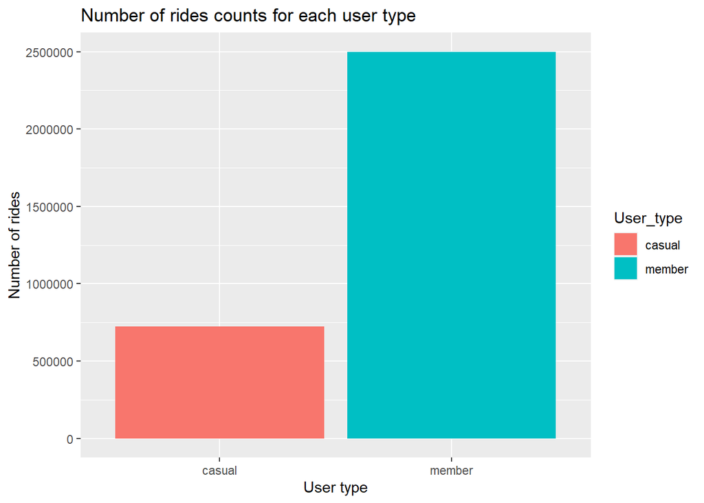

```r
ggplot(data=user_type_ridecounts, aes(x = User_type, y = count, fill = User_type)) +
  geom_bar(stat = "identity") + labs(title = 'Number of rides counts for each user type', x = 'User type', y = 'Number of rides')
```

2. Calculate how much each type of riders spend time renting the bikes

```
## Defaulting to continuous.
```

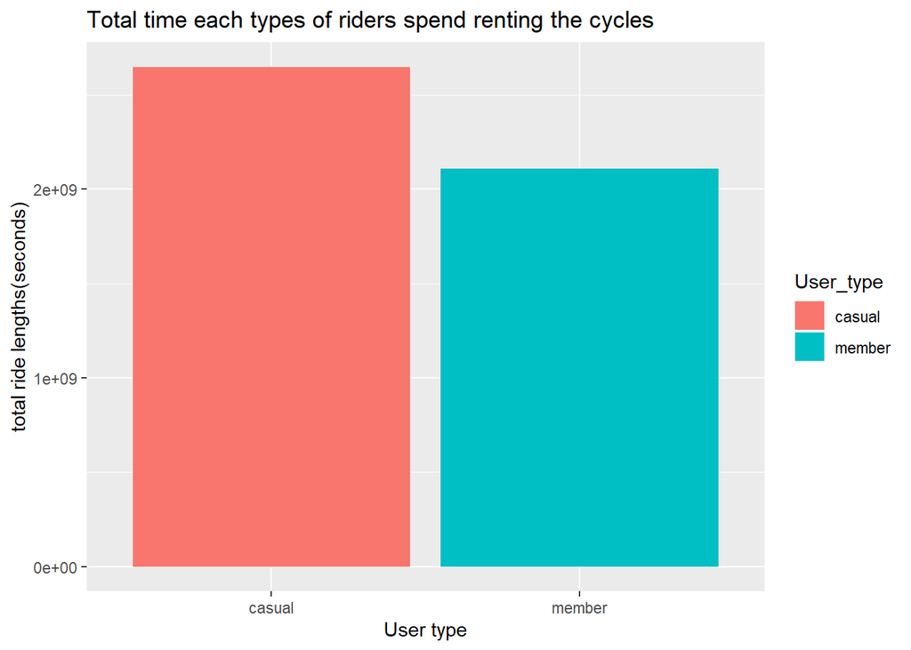

```r
ggplot(data=trip_duration, aes(x = User_type, y = total_time, fill = User_type)) +
  geom_bar(stat = "identity") +labs(title = 'Total time each types of riders spend renting the cycles', x = 'User type', y = 'total ride lengths(seconds)')
```

6.1 See the ride_lengths in each day of weekday

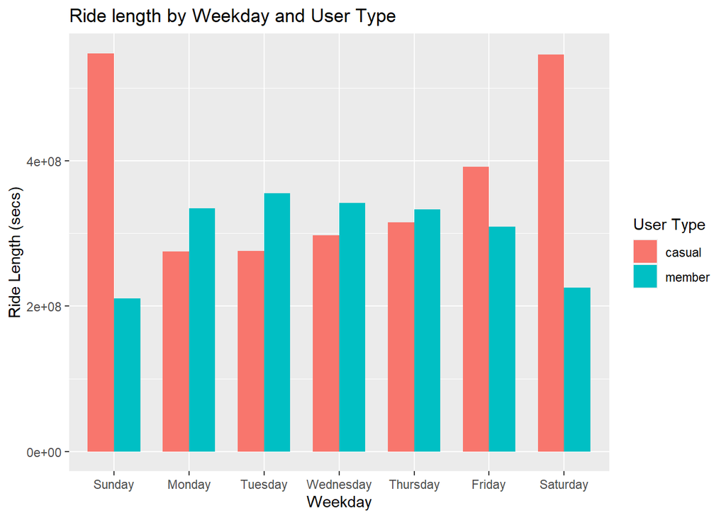

```r
ggplot(weekly_rides_summary, aes(x = Weekday, y = Total_Ride_Length, fill = User_type)) +
  geom_bar(stat = 'identity', position = position_dodge(), width = 0.7) +
  labs(title = 'Ride length by Weekday and User Type', x = 'Weekday', y = 'Ride Length (secs)') +
  scale_fill_discrete(name = 'User Type')
```

6.2 See the number of rides ie no of rents of cycles in each day of weekdays

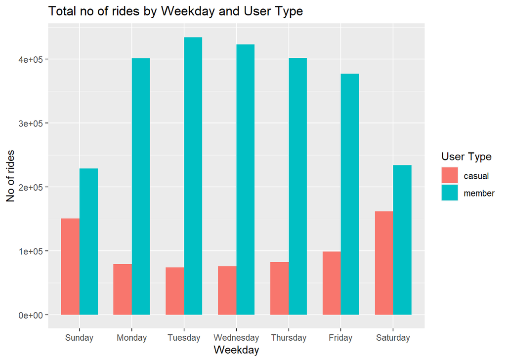

```r
ggplot(weekly_rides_summary, aes(x = Weekday, y = total_rides, fill = User_type)) +
  geom_bar(stat = 'identity', position = position_dodge(), width = 0.7) +
  labs(title = 'Total no of rides by Weekday and User Type', x = 'Weekday', y = 'No of rides') +
  scale_fill_discrete(name = 'User Type')
```

7.1 line plot showing the Ride Length by Month and User Type

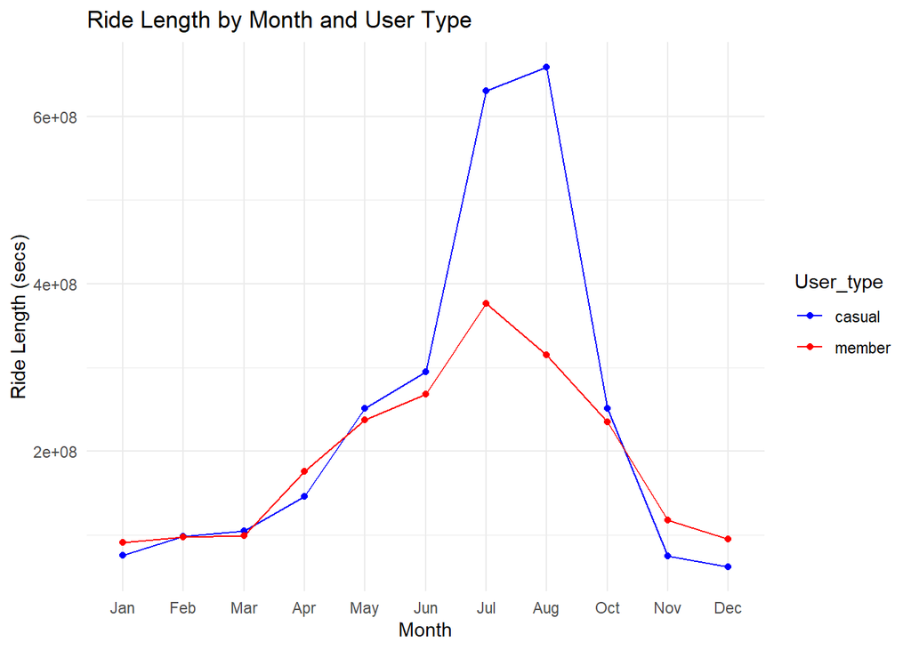

```r
ggplot(monthly_rides_summary, aes(x = Month, y = Total_Ride_Length, group = User_type, color = User_type)) +
  geom_line() +
  geom_point() +
  labs(title = "Ride Length by Month and User Type" , x = "Month", y = "Ride Length (secs)") +
  scale_color_manual(values = c("casual" = "blue", "member" = "red")) +
  theme_minimal()
```

7.2 line plot showing the number of rides rented each month by each user type

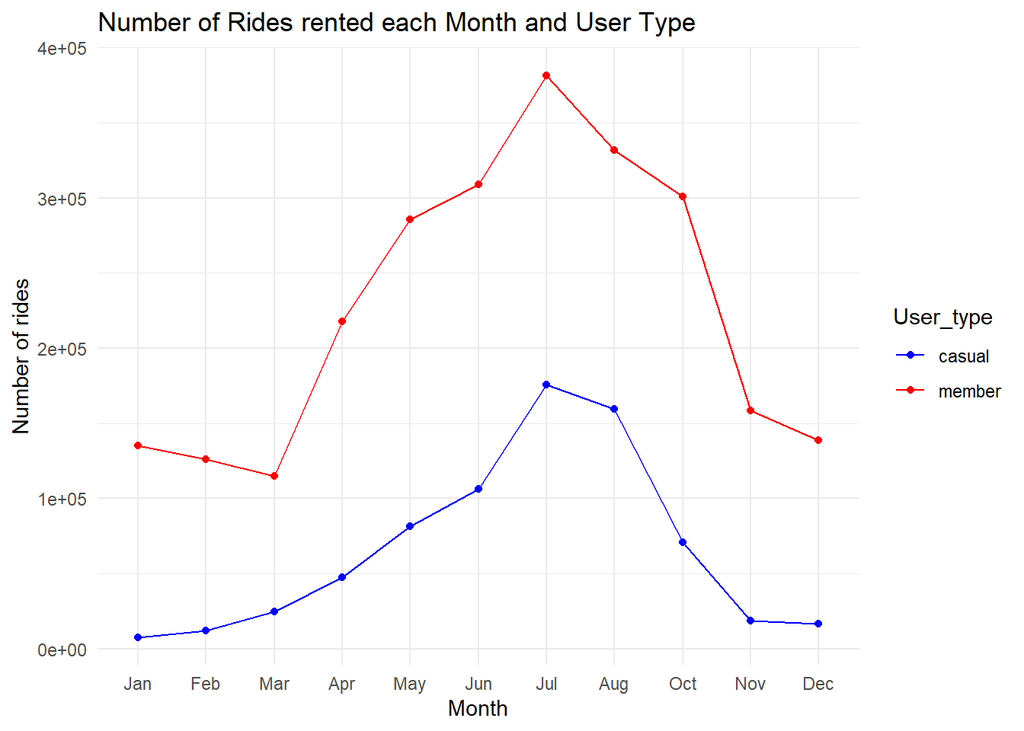

```r
ggplot(monthly_rides_summary, aes(x = Month, y = total_rides, group = User_type, color = User_type)) +
  geom_line() +
  geom_point() +
  labs(title = "Number of Rides rented each Month and User Type" , x = "Month", y = "Number of rides",) +
  scale_color_manual(values = c("casual" = "blue", "member" = "red")) +
  theme_minimal()
```

8. Looking the top 10 most popular starting station for both the user types

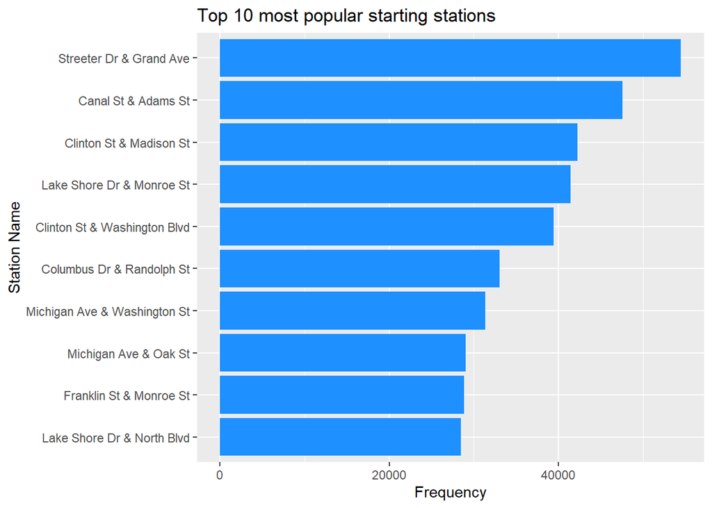

```r
ggplot(Starting_Station_counts, aes(y = reorder(From_Station_Name, frequency), x = frequency)) +
  geom_bar(stat = "identity", fill = "dodgerblue") +
  labs(title = "Top 10 most popular starting stations", x = "Frequency", y = "Station Name")
```

9. Looking the top 10 popular starting station for casual user type

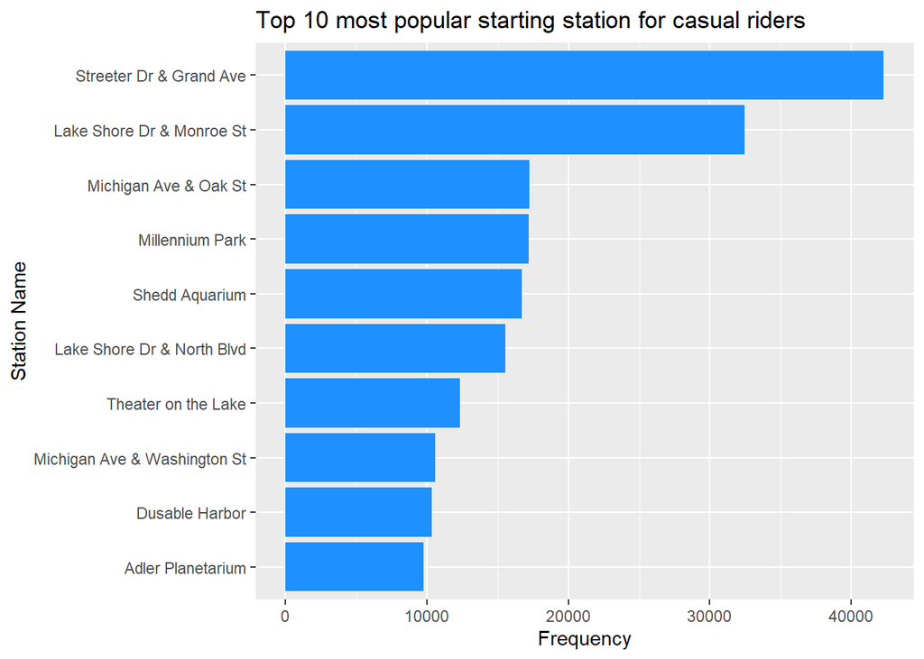

```r
ggplot(Starting_Station_casual, aes(y = reorder(From_Station_Name, frequency), x = frequency)) +
  geom_bar(stat = "identity", fill = "dodgerblue") +
  labs(title = "Top 10 most popular starting station for casual riders", x = "Frequency", y = "Station Name")
```

10. Top 10 most popular ending station for both the user types

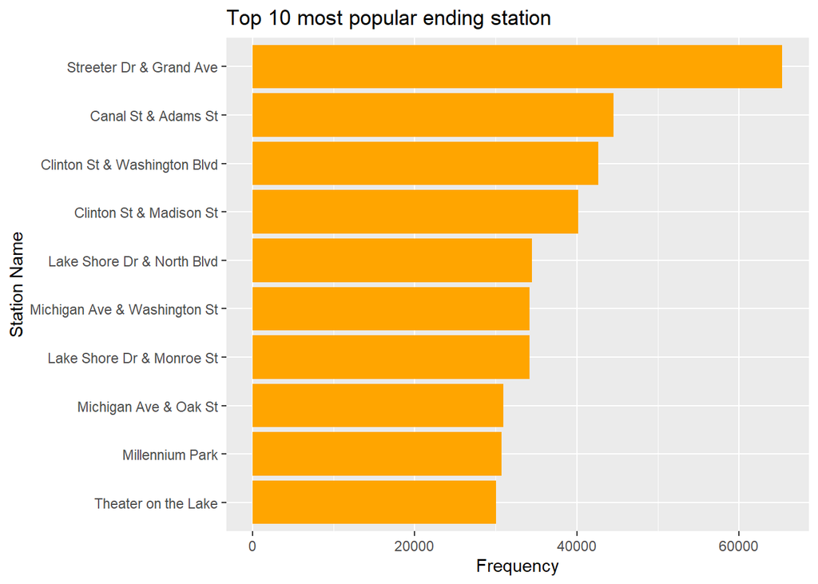

```r
ggplot(Ending_station_counts, aes(y = reorder(To_Station_Name, frequency), x = frequency)) +
  geom_bar(stat = "identity", fill = "orange") +
  labs(title = "Top 10 most popular ending station", x = "Frequency", y = "Station Name")
```

11. Looking top 10 popular ending station for casual user type

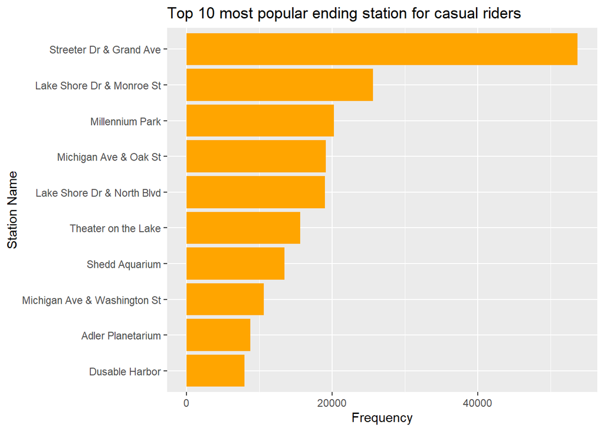

```r
ggplot(Ending_Station_casual, aes(y = reorder(To_Station_Name, frequency), x = frequency)) +
  geom_bar(stat = "identity", fill = "orange") +
  labs(title = "Top 10 most popular ending station for casual riders", x = "Frequency", y = "Station Name")
```

## Step 6. Act Phase

This is the last phase where I give my observations and some recommendations on how to improve the business.

### Observations

The major observations based on my case study are given below:  
• Member riders are about 3.4 times than the casual riders which means that member rent the bikes more often than casual riders.  
• Time spent to rent the bikes by casual riders is more compared to member.  
• Casual riders rented the bikes mostly during weekends ie Saturday and Sunday. Whereas members rented most on Tuesday and Wednesday.  
• Casual riders spent most time renting the bikes during weekends ie Saturday and Sunday whereas members spend most time on Tuesday and Wednesday.  
• Both casual and member riders spent most time renting the bikes during summer ie the month of July and August. Similarly, the highest number of rides rented is also in summer for both the user types.  
• Out of 643 unique starting stations and 644 unique ending stations, the most popular starting and ending station is Street Dr & Grand Ave for casual riders.

### Conclusion

• There are about 3.4 times more member riders than casual riders, showing that the bike-sharing service is preferred by regular users who probably like the membership benefits.  
• Casual riders rent bikes for longer periods than members, suggesting they use them for fun, picnics or longer trips, while members use it for shorter rides.  
• Casual riders like renting bikes mostly on weekends (Saturday and Sunday) for fun, while members use them more on Tuesday and Wednesday, likely for regular commuting.  
• Both casual and member riders prefer renting bikes in summer (July and August), possibly because of more favorable weather and more outdoor activities.  
• Casual riders prefer starting and ending at Street Dr & Grand Ave station, possibly because it’s centrally located or close to recreational areas.

### Recommendations

My recommendation to convert the casual riders to members riders are given below:  
• Offer a discounted weekend trial membership for casual riders so that they can enjoy member benefits on weekends. If they like it, they might choose the annual membership.  
• Make packages with a few rides at lower prices. Like a bundle of 10 rides for less than buying one by one. This helps casual riders try membership benefits and consider getting a yearly plan.  
• Offer a special summer membership with access to bike variety and ride discounts for July and August. Show how it saves money and is convenient suiting their active summer. This may get casual riders to try membership perks and convert to annual member.  
• Promote the benefits of membership by highlighting exclusive access to the most popular Street Dr & Grand Ave starting and ending station and other top popular stations.